# Data Storytelling and Insight

Tan Thien Nguyen

# 1. Introduction

Many people believe that Agriculture, Forestry, and Fishing contribute a big part to the world’s economy (Gapminder, 2021). Vietnam, one of the countries in the lower-middle-income group, has a lot of advantages about natural resources for Agriculture, Forestry, and Fishing development. The amount of Agriculture and Fishing goods exports increased over the years and the labor force working in Agriculture in Vietnam is more significant than any economic activity. The target of Vietnam is reaching the high-income group by the year 2045 (World Bank, 2020). Whether Vietnam should treat Agriculture, Forestry, and Fishing as the spearhead of the economy to reach the target make a controversy among community. It is not enough to evaluate sufficiently situation and direction if only look into Vietnam’s strength and what Vietnam has in history. This report aims to clarify the above problem by analyzing data from the World Bank.

# 2. Problem Statement, rationale and Research Question

## 2.1. Problem Statement

The world is developing very fast. Countries are all trying to improve their economies to provide a better life for their people and enhance their international standing. In addition to that, United Nations also recommends countries focus on sustainable development goals. That is even more important for low-middle-income countries like Vietnam when the gap with high-income countries is not small. Determining where the economic sector needs to increase its share of GDP plays an essential role in achieving the economic goal and sustainable growth.

## 2.2. Rationale

The decision to focus on which economic sector is significant. It is definitely the key part for the economy to move forward or backward. Choosing the right direction will boost the GDP and improve resident living quality, whereas choosing the wrong direction will decline the GDP. However, every decision should be made based on data, which has better ideas.

## 2.3. Research Question

“Which economic sector should Vietnam - a lower and middle income country - with favorable natural conditions for the development of Agriculture, Forestry, and Fishing increase the share of GDP to reach High-income group?”

# 3. Data Presentation

## 3.1. Dataset description

The datasets are gathered from the Databank of World Bank (https://databank.worldbank.org/home.aspx) with the last updated date on December 16, 2021. The name of datasets will then be changed for easy understanding and usage.

### Country Dataset (Metadata_Country_API_NY.GDP.PCAP.CD)

Country dataset contains 217 countries and regions around the world. Countries are grouped by region and income group (World Bank, 2021).

### Population Total(SP.POP.TOTL)

Total population is based on the de facto definition of population, which counts all residents regardless of legal status or citizenship. The values shown are midyear estimates (World Bank, 2021).

### GDP per capita (current US$) (NY.GDP.PCAP.CD)

GDP per capita is gross domestic product divided by midyear population. GDP is the sum of gross value added by all resident producers in the economy plus any product taxes and minus any subsidies not included in the value of the products. It is calculated without making deductions for depreciation of fabricated assets or depletion and degradation of natural resources (World Bank, 2021).

## 3.2. Tidy Data

Tidy datasets provide a standardized way to link the structure of a dataset (its physical layout) with its semantics (its meaning) (R Foundation, 2021).

There are three interrelated rules which make a dataset tidy (R for Data Science, 2021):

- Each variable must have its own column.
- Each observation must have its own row.
- Each value must have its own cell.

## 3.3. Data Combination

The datasets extracted from World Bank contain information separately and insufficiently. Therefore, some datasets will be joined together to get enough information for data analysis. For example, the GDP dataset will be joined with the Country dataset to get CountryCode, CountryName, GDP through years, Region, and Income Group.

# 4. Data Manipulation

The datasets collected from World Bank are not in the tidy format. In addition, there are several unclean data and columns with the wrong name.

Therefore, the datasets will be loaded, cleaned, transformed to the tidy format, corrected column names in this section.

Due to the effect of Covid-19 on worldwide GDP, the data for the year 2020 would be considered to be removed before data analysis.

## 4.1. Libraries

The libraries used for data analysis are listed below. If you would like to run R code, please kindly install these packages first.

```r
# install.packages("gganimate")
# install.packages("gifski")
# install.packages('png')

library(dplyr)
library(ggplot2)
library(tidyverse)
library(plotly)
library(gganimate)
library(gifski)
library(png)
```

## 4.2. Data Loading

### 4.2.1. Import Datasets.

Datasets were imported from csv files

```r
# Get data from csv files
country <- read.csv("Dataset/country.csv")
population <- read.csv("Dataset/population_total.csv")
gdp <- read.csv("Dataset/gdp.csv")
agripercent <- read.csv("Dataset/agri_percent.csv")
agritotal <- read.csv("Dataset/agri_total.csv")
industrypercent <- read.csv("Dataset/industry_percent.csv")
servicepercent <- read.csv("Dataset/service_percent.csv")
tourism_arr <- read.csv("Dataset/tourism_arrival.csv")
tourism_receipt <- read.csv("Dataset/tourism_receipt.csv")
emp_agri <- read.csv("Dataset/emp_agri.csv")
emp_industry <- read.csv("Dataset/emp_industry.csv")
emp_service <- read.csv("Dataset/emp_service.csv")
```

### 4.2.2. Datasets Summary

All datasets collected from World Bank have the same structure as below:

- Country.Name: Name of countries
- Country.Code: Country code of countries
- Indicator.Name: Definition of dataset (e.g. “GDP per capita (current US$)” )
- Indicator.Code: Code of Indicator.Name (e.g. “NY.GDP.PCAP.CD”)
- X196i -> X202i: Year columns contain data

Below is the summary and structure of an example dataset - GDP Per Capita.

Because there is a lot of year columns and their structures are the same, the first year column “X1960” will be selected to be pulled out:

```r
# Datasets summary
cols <- c("ï..Country.Name", "Country.Code"  ,  "Indicator.Name" , "Indicator.Code" , "X1960")

summary(gdp[cols])
```

```
##  ï..Country.Name    Country.Code       Indicator.Name     Indicator.Code
##  Length:266         Length:266         Length:266         Length:266
##  Class :character   Class :character   Class :character   Class :character
##  Mode  :character   Mode  :character   Mode  :character   Mode  :character
##
##
##
##
##      X1960
##  Min.   :  40.54
##  1st Qu.: 104.41
##  Median : 197.90
##  Mean   : 482.74
##  3rd Qu.: 478.83
##  Max.   :3007.12
##  NA's   :138
```

```r
str(gdp[cols])
```

```
## 'data.frame':    266 obs. of  5 variables:
##  $ ï..Country.Name: chr  "Aruba" "Africa Eastern and Southern" "Afghanistan" "Africa Western and Central" ...
##  $ Country.Code   : chr  "ABW" "AFE" "AFG" "AFW" ...
##  $ Indicator.Name : chr  "GDP per capita (current US$)" "GDP per capita (current US$)" "GDP per capita (current US$)" "GDP per capita (current US$)" ...
##  $ Indicator.Code : chr  "NY.GDP.PCAP.CD" "NY.GDP.PCAP.CD" "NY.GDP.PCAP.CD" "NY.GDP.PCAP.CD" ...
##  $ X1960          : num  NA 147.5 59.8 107.9 NA ...
```

## 4.3. Data Cleaning

Rename some columns, select only necessary columns for data analysis, and exclude the year 2020 due to Covid-19 affected a lot in the world economy.

```r
# Country
country <- country %>%
  filter(Region != "" & IncomeGroup != "") %>%
  rename(CountryCode = ï..CountryCode)%>%
  rename(CountryName = TableName) %>%
  select(CountryCode, Region, IncomeGroup, CountryName)

# GDP per capita
gdp <- gdp %>%
  rename(CountryName = ï..Country.Name)%>%
  rename(CountryCode = Country.Code) %>%
  select(CountryCode, CountryName, contains("X"), -c(X,X2020))

# Population
population <- population %>%
  rename(CountryName = ï..Country.Name)%>%
  rename(CountryCode = Country.Code) %>%
  select(CountryCode, CountryName, contains("X"), -c(X,X2020))

# Agriculture % GDP
agripercent <- agripercent %>%
  rename(CountryName = ï..Country.Name)%>%
  rename(CountryCode = Country.Code) %>%
  select(CountryCode, CountryName, contains("X"), -c(X,X2020))

# Agriculture Total
agritotal <- agritotal %>%
  rename(CountryName = ï..Country.Name)%>%
  rename(CountryCode = Country.Code) %>%
  select(CountryCode, CountryName, contains("X"), -c(X,X2020))

# Industry % GDP
industrypercent <- industrypercent %>%
  rename(CountryName = ï..Country.Name)%>%
  rename(CountryCode = Country.Code) %>%
  select(CountryCode, CountryName, contains("X"), -c(X,X2020))

# Service % GDP
servicepercent <- servicepercent %>%
  rename(CountryName = ï..Country.Name)%>%
  rename(CountryCode = Country.Code) %>%
  select(CountryCode, CountryName, contains("X"), -c(X,X2020))

# International Tourism Arrival
tourism_arr <- tourism_arr %>%
  rename(CountryName = ï..Country.Name)%>%
  rename(CountryCode = Country.Code) %>%
  select(CountryCode, CountryName, contains("X"), -c(X,X2020))

# International Tourism Receipt
tourism_receipt <- tourism_receipt %>%
  rename(CountryName = ï..Country.Name)%>%
  rename(CountryCode = Country.Code) %>%
  select(CountryCode, CountryName, contains("X"), -c(X,X2020))

# Employment Pct in Agriculture
emp_agri <- emp_agri %>%
  rename(CountryName = ï..Country.Name)%>%
  rename(CountryCode = Country.Code) %>%
  select(CountryCode, CountryName, contains("X"), -c(X,X2020))

# Employment Pct in Industry
emp_industry <- emp_industry %>%
  rename(CountryName = ï..Country.Name)%>%
  rename(CountryCode = Country.Code) %>%
  select(CountryCode, CountryName, contains("X"), -c(X,X2020))

# Employment Pct in Service
emp_service <- emp_service %>%
  rename(CountryName = ï..Country.Name)%>%
  rename(CountryCode = Country.Code) %>%
  select(CountryCode, CountryName, contains("X"), -c(X,X2020))
```

## 4.4. Data combination

Join datasets to get sufficient attributes

```r
# GDP join Country
gdp_group <- gdp %>%
  inner_join(country,by="CountryCode") %>%
  select(CountryCode, CountryName.x, Region, IncomeGroup, contains("X"))%>%
  rename(CountryName = CountryName.x)

# Population join Country
population_group <- population %>%
  inner_join(country,by="CountryCode") %>%
  select(CountryCode, CountryName.x, Region, IncomeGroup, contains("X"))%>%
  rename(CountryName = CountryName.x)

# Agripercent join Country
agripercent_group <- agripercent %>%
  inner_join(country,by="CountryCode") %>%
  select(CountryCode, CountryName.x, Region, IncomeGroup, contains("X"))%>%
  rename(CountryName = CountryName.x)

# Agripercent join Country
agritotal_group <- agritotal %>%
  inner_join(country,by="CountryCode") %>%
  select(CountryCode, CountryName.x, Region, IncomeGroup, contains("X"))%>%
  rename(CountryName = CountryName.x)

# Industrypercent join Country
industrypercent_group <- industrypercent %>%
  inner_join(country,by="CountryCode") %>%
  select(CountryCode, CountryName.x, Region, IncomeGroup, contains("X"))%>%
  rename(CountryName = CountryName.x)

# Servicepercent join Country
servicepercent_group <- servicepercent %>%
  inner_join(country,by="CountryCode") %>%
  select(CountryCode, CountryName.x, Region, IncomeGroup, contains("X"))%>%
  rename(CountryName = CountryName.x)
```

## 4.5. Transform to Tidy Data

Transform datasets to the tidy data and convert Year column into Date format

```r
# Transform GDP to tidy data
gdp_new <- gdp_group %>%
  pivot_longer(!c("CountryCode","CountryName","Region","IncomeGroup"), names_to = "Year", values_to = "GDP") %>%
  mutate(Year = str_remove(Year,"X"),
         Year = as.integer(Year))

# Transform GDP to tidy data
population_new <- population_group %>%
  pivot_longer(!c("CountryCode","CountryName","Region","IncomeGroup"), names_to = "Year", values_to = "GDP") %>%
  mutate(Year = str_remove(Year,"X"),
         Year = as.integer(Year))

# Transform Agripercent to tidy data
agripercent_new <- agripercent_group %>%
  pivot_longer(!c("CountryCode","CountryName","Region","IncomeGroup"), names_to = "Year", values_to = "GDP") %>%
  mutate(Year = str_remove(Year,"X"),
         Year = as.integer(Year))

# Transform Agripercent to tidy data
agritotal_new <- agritotal_group %>%
  pivot_longer(!c("CountryCode","CountryName","Region","IncomeGroup"), names_to = "Year", values_to = "GDP") %>%
  mutate(Year = str_remove(Year,"X"),
         Year = as.integer(Year))

# Transform Industrypercent to tidy data
industrypercent_new <- industrypercent_group %>%
  pivot_longer(!c("CountryCode","CountryName","Region","IncomeGroup"), names_to = "Year", values_to = "GDP") %>%
  mutate(Year = str_remove(Year,"X"),
         Year = as.integer(Year))

# Transform Servicepercent to tidy data
servicepercent_new <- servicepercent_group %>%
  pivot_longer(!c("CountryCode","CountryName","Region","IncomeGroup"), names_to = "Year", values_to = "GDP") %>%
  mutate(Year = str_remove(Year,"X"),
         Year = as.integer(Year))

# Transform tourism arrivals to tidy data
tourism_arr_new <- tourism_arr %>%
  pivot_longer(!c("CountryCode","CountryName"), names_to = "Year", values_to = "GDP") %>%
  mutate(Year = str_remove(Year,"X"),
         Year = as.integer(Year))

# Transform tourism receipt to tidy data
tourism_receipt_new <- tourism_receipt %>%
  pivot_longer(!c("CountryCode","CountryName"), names_to = "Year", values_to = "GDP") %>%
  mutate(Year = str_remove(Year,"X"),
         Year = as.integer(Year))

# Transform tourism receipt to tidy data
emp_agri_new <- emp_agri %>%
  pivot_longer(!c("CountryCode","CountryName"), names_to = "Year", values_to = "Agriculture") %>%
  mutate(Year = str_remove(Year,"X"),
         Year = as.integer(Year))

# Transform tourism receipt to tidy data
emp_industry_new <- emp_industry %>%
  pivot_longer(!c("CountryCode","CountryName"), names_to = "Year", values_to = "Industry") %>%
  mutate(Year = str_remove(Year,"X"),
         Year = as.integer(Year))

# Transform tourism receipt to tidy data
emp_service_new <- emp_service %>%
  pivot_longer(!c("CountryCode","CountryName"), names_to = "Year", values_to = "Service") %>%
  mutate(Year = str_remove(Year,"X"),
         Year = as.integer(Year))
```

## 4.6. Data Pre-processing for Visualization

### 4.6.1. Merge employment percentage datasets

Employment percentages datasets will be merged for comparation.

```r
emp_percent <- emp_agri_new %>%
  inner_join(emp_industry_new, by = c("CountryCode", "Year")) %>%
  inner_join(emp_service_new, by = c("CountryCode", "Year")) %>%
  select(CountryCode, CountryName.x, Year, Agriculture, Industry,Service)%>%
  rename(CountryName = CountryName.x)

emp_percent_new <- emp_percent %>%
  pivot_longer(!c("CountryCode","CountryName","Year"), names_to = "Sector", values_to = "Percentage")
```

### 4.6.2. Create new datasets and variables

GDP and other economic sectors information will be pre-processed here.

```r
# GDP

world <- gdp_new %>%
  group_by(Year) %>%
  summarise(avg_GDP = mean(GDP, na.rm = TRUE)) %>%
  mutate(Country = "World") %>%
  rename(GDP = avg_GDP) %>%
  select(Country,Year,GDP)

high_low_middle <- gdp_new %>%
  filter(IncomeGroup %in% c("High income", "Upper middle income")) %>%
  group_by(IncomeGroup, Year) %>%
  summarise(avg_GDP = mean(GDP, na.rm = TRUE)) %>%
  rename(Country = IncomeGroup,
         GDP = avg_GDP)%>%
  select(Country,Year,GDP)

Vietnam <- gdp_new %>%
  filter(CountryCode %in% c("VNM")) %>%
  rename(Country = CountryName)%>%
  select(Country,Year,GDP)

gdp_graph <- rbind(world,high_low_middle,Vietnam)

# Agriculture Percent

agri_world <- agripercent_new %>%
  group_by(Year) %>%
  summarise(avg_GDP = mean(GDP, na.rm = TRUE)) %>%
  mutate(Country = "World") %>%
  rename(GDP = avg_GDP) %>%
  select(Country,Year,GDP)

agri_group <- agripercent_new %>%
  filter(IncomeGroup %in% c("High income", "Lower middle income", "Upper middle income", "Low income")) %>%
  group_by(IncomeGroup, Year) %>%
  summarise(avg_GDP = mean(GDP, na.rm = TRUE)) %>%
  rename(Country = IncomeGroup,
         GDP = avg_GDP)%>%
  select(Country,Year,GDP)

agri_vietnam <- agripercent_new %>%
  filter(CountryCode %in% c("VNM")) %>%
  rename(Country = CountryName)%>%
  select(Country,Year,GDP)

agripercent_graph <- rbind(agri_world,agri_group,agri_vietnam)

# Industry Percent

industry_world <- industrypercent_new %>%
  group_by(Year) %>%
  summarise(avg_GDP = mean(GDP, na.rm = TRUE)) %>%
  mutate(Country = "World") %>%
  rename(GDP = avg_GDP) %>%
  select(Country,Year,GDP)

industry_group <- industrypercent_new %>%
  filter(IncomeGroup %in% c("High income", "Lower middle income", "Upper middle income", "Low income")) %>%
  group_by(IncomeGroup, Year) %>%
  summarise(avg_GDP = mean(GDP, na.rm = TRUE)) %>%
  rename(Country = IncomeGroup,
         GDP = avg_GDP)%>%
  select(Country,Year,GDP)

industry_vietnam <- industrypercent_new %>%
  filter(CountryCode %in% c("VNM")) %>%
  rename(Country = CountryName)%>%
  select(Country,Year,GDP)

industrypercent_graph <- rbind(industry_world,industry_group,industry_vietnam)

# Service Percent

service_world <- servicepercent_new %>%
  group_by(Year) %>%
  summarise(avg_GDP = mean(GDP, na.rm = TRUE)) %>%
  mutate(Country = "World") %>%
  rename(GDP = avg_GDP) %>%
  select(Country,Year,GDP)

service_group <- servicepercent_new %>%
  filter(IncomeGroup %in% c("High income", "Lower middle income", "Upper middle income", "Low income")) %>%
  group_by(IncomeGroup, Year) %>%
  summarise(avg_GDP = mean(GDP, na.rm = TRUE)) %>%
  rename(Country = IncomeGroup,
         GDP = avg_GDP)%>%
  select(Country,Year,GDP)

service_vietnam <- servicepercent_new %>%
  filter(CountryCode %in% c("VNM")) %>%
  rename(Country = CountryName)%>%
  select(Country,Year,GDP)

servicepercent_graph <- rbind(service_world,service_group,service_vietnam)

# Merge service and gdp

service_gdp <- servicepercent_new %>%
  inner_join(gdp_new, by = c("CountryCode","CountryName","Year","Region","IncomeGroup")) %>%
  inner_join(population_new, by = c("CountryCode","CountryName","Year","Region","IncomeGroup")) %>%
  rename(ServiceInGDP = GDP.x,
         GDPPerCapita = GDP.y,
         Population = GDP) %>%
  mutate(Population = Population/1000000)
```

Data cleaning and data transformation was completed. Now, it is time to go to the most interesting part. Visualization.

# 5. Data Visualization and Storytelling

This part is designed as a story, therefore, several words used in this part will be like as in a story. Let’s start.

First, we will look into the workforce in Vietnam.

### Graph 1. Distribution of Total Employment in Vietnam over years (%)

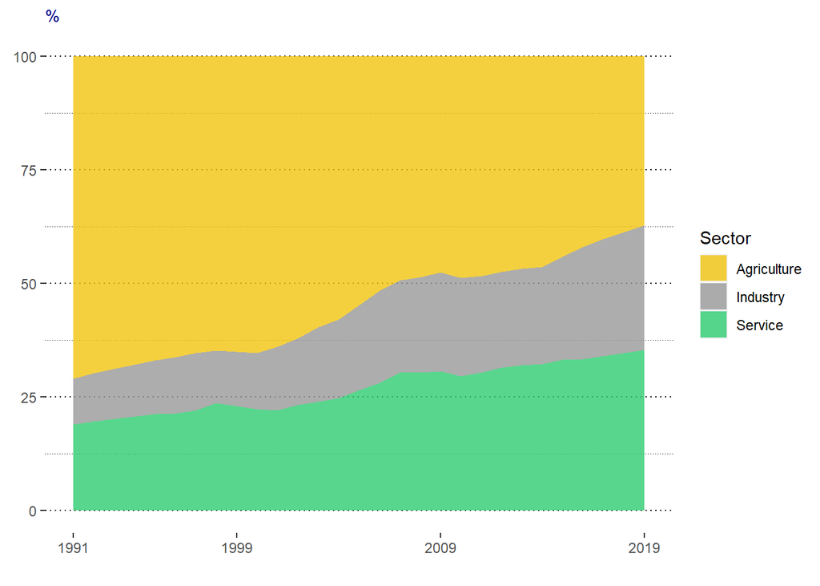

The number of labors working in Agriculture in Vietnam is bigger than any economic activity.

And next, we will see the GDP of Vietnam and other countries to see where Vietnam is standing.

### Graph 2. GDP per capita (US Dollars) of Vietnam, high-income, upper middle income group and the world

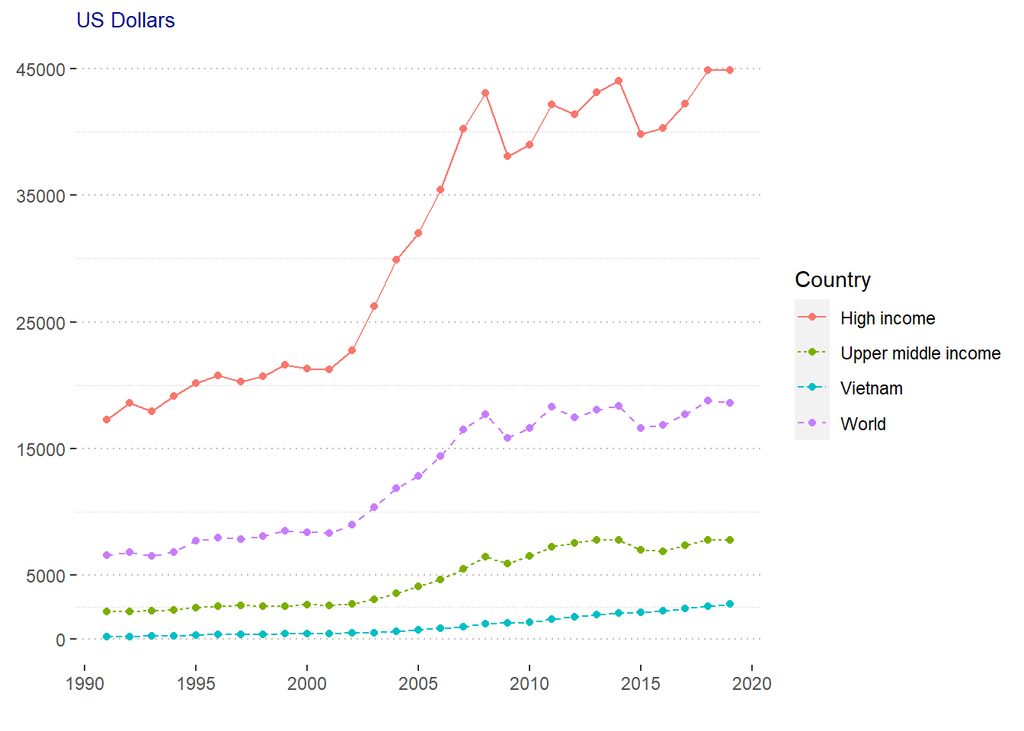

Vietnam is still standing in an honesty position. There is a considerable distance in GDP per capita between Vietnam and the world. Vietnam must try a lot to reach their target of the high-income group in 2045. Vietnam must determine which sector they should focus on to achieve this target. Vietnam also has favorable natural conditions for Agriculture, Forestry, and Fishing development

In a survey on gapmider.org, many people think Agriculture, Forestry and Fishing (AFF) contribute a big part in the world economy (Gapminder, 2021). But Let see what data say

### Graph 3. Agriculture, forestry, and fishing, value added (% of GDP) over years for the world

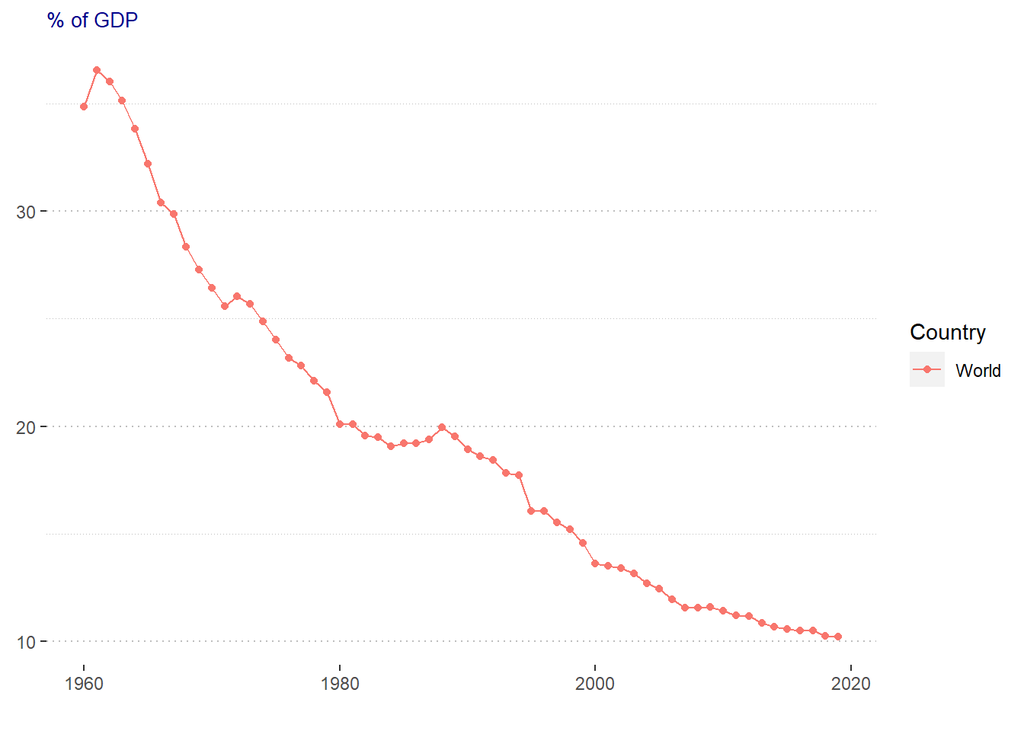

Oh no. AFF hadn’t reached 30% GDP of the world in 50 years, and only around 10% GDP of the world in the last decade.

But it is the average number for whole the world. We will add Vietnam, high income, upper middle income, lower and middle income group, and even low income into the chart.

### Graph 4. Agriculture, forestry, and fishing, value added (% of GDP) for all groups and Vietnam

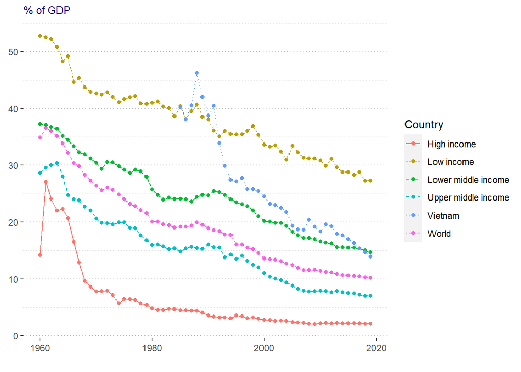

Even in the low income group, the percentage of AFF to their economy is decreasing.

But wait, how about countries that has the biggest amount of agriculture in the world?

### Graph 5. The top 5 countries that has biggest Agriculture total amount in 2019 (US$ Billion)

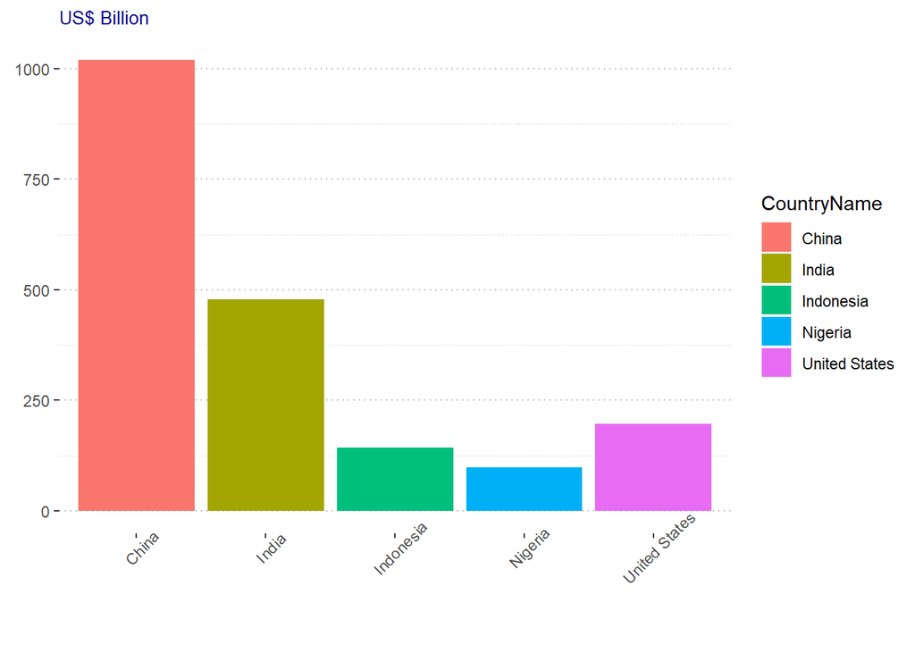

China, India, Indonesia, Nigeria, and the United States are the top 5 countries with the enormous Agriculture amount now. What about the percentage of AFF contributing to their economy?

### Graph 6. Agriculture, forestry, and fishing, value added (% of GDP) of top 5 countries

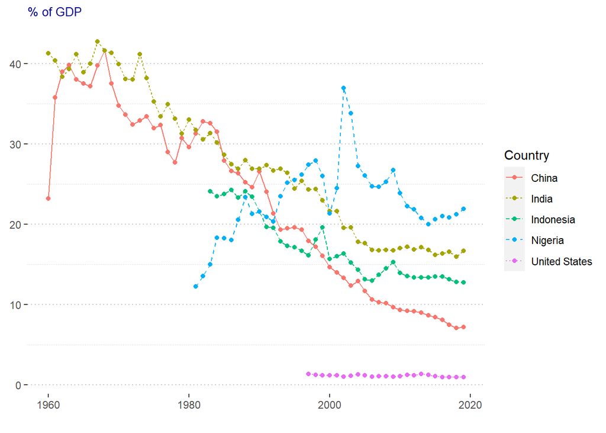

If it is not Agri, which sector is the world focusing on? Whether it is industry. Let take a look.

### Graph 7. Industries, value added (% of GDP) over years for the world

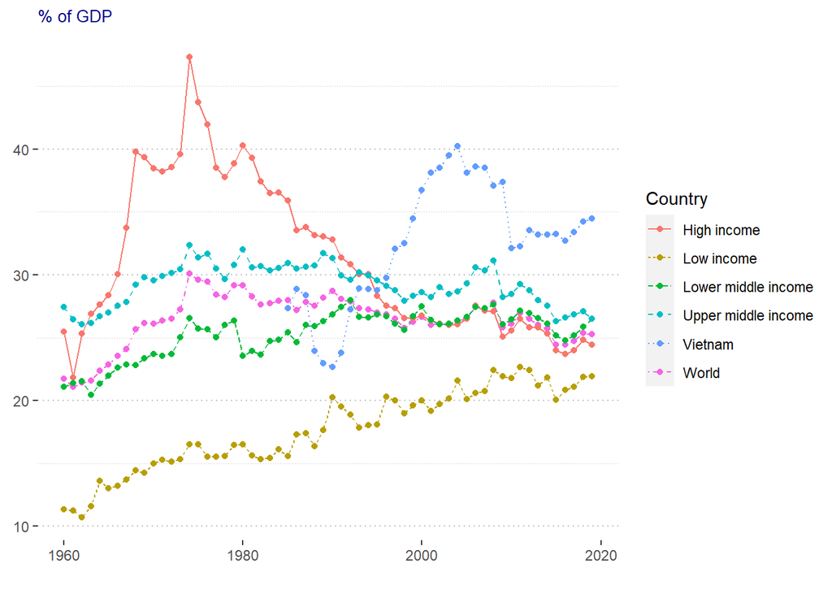

The Low income group focuses on this. The Lower middle income (Vietnam in this group) also focus on this.

But the high income, upper middle income group and the world don’t.

We still have another sector - Service. Let see what data tell us about it.

### Graph 8. Services, value added (% of GDP) over years for the world

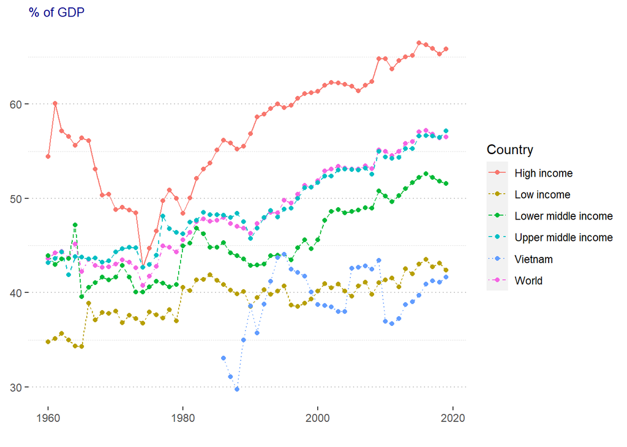

Aha. Here we go. The service sector is definitely the ONE.

But wait, we will see whether GDP increases the over years while countries are moving their concentration on the Services.

### Graph 9. GDP per capita and Services Percentage of GDP over years.

This part is created based on the idea of Hans Rosling. Please Please refer to GDPandService.gif file (auto generated in the same folder) or knit HTML format or run the Rmarkdown watch the animation because it is impossible to see it in Word.

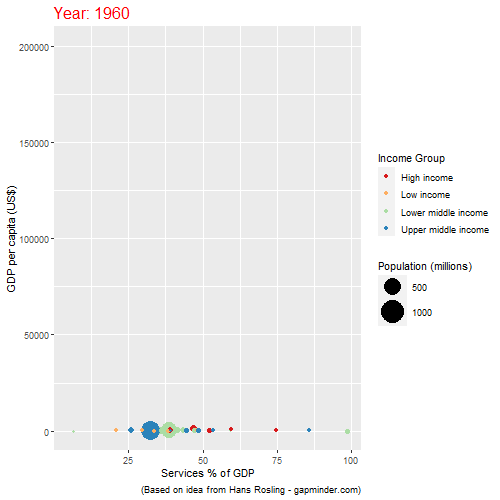

### Graph 10. How the world evolve after 30 years

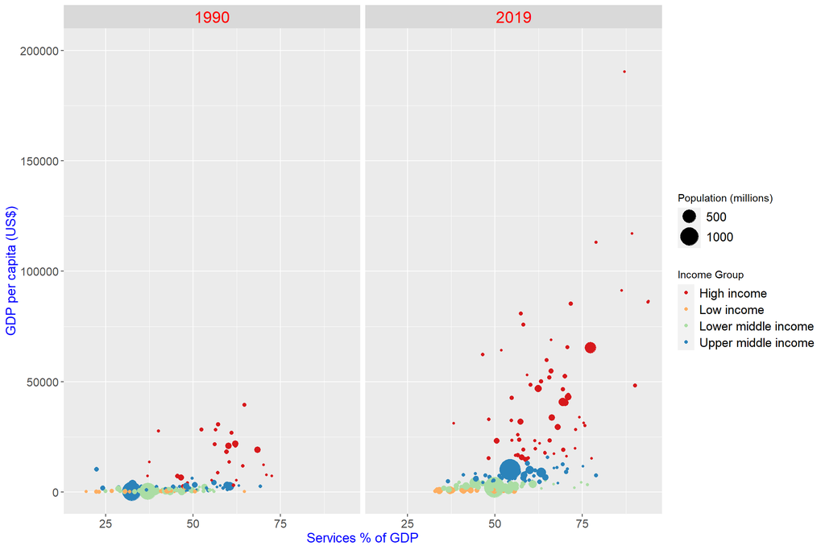

Now we are pretty sure that, the Services sector is the way Vietnam should go.

Next, we will look in more detail at one of the most popular services in the world, which is considered as one of Economic Sustainable Development Goals - Tourism, to see what Vietnam could do.

We will compare the difference in the number of International arrivals and receipts between Vietnam and another country in the same region with nearly the same natural conditions, Thailand.

### Graph 11. Number of International Arrivals (Millions) in Vietnam and Thailand

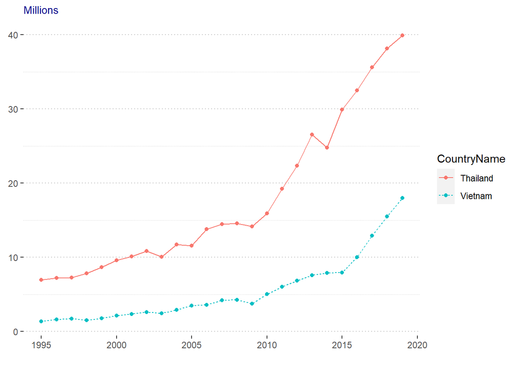

### Graph 12. International Tourism Receipts (US$ Billion) of Vietnam and Thailand

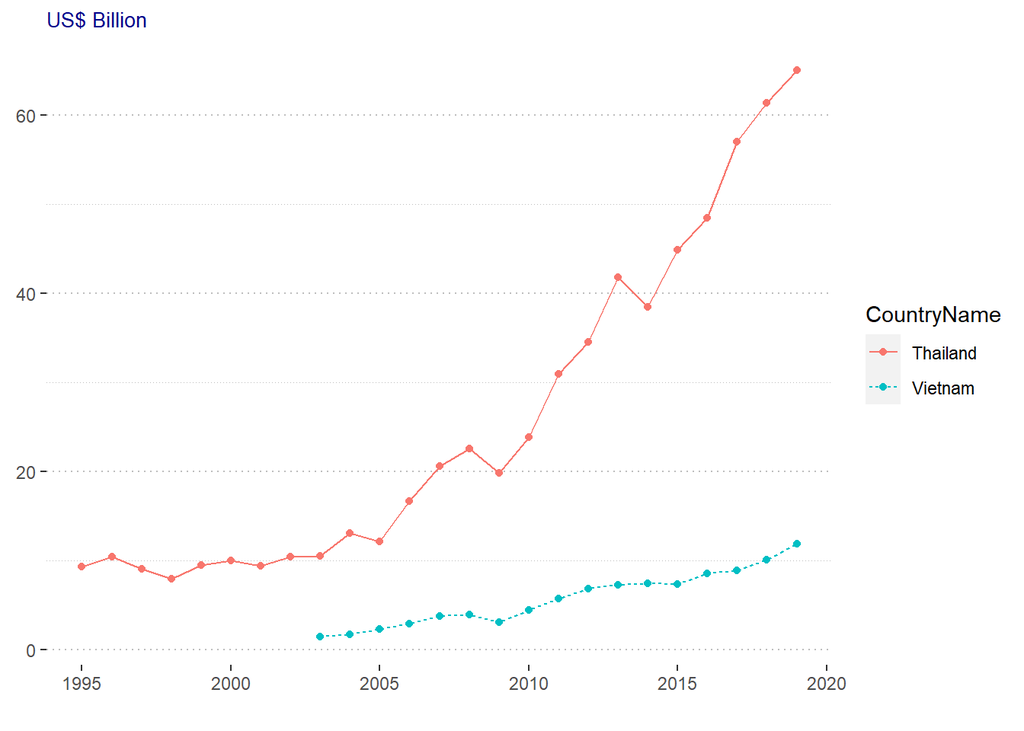

# 6. Conclusion and discussion

The report showed that Vietnam should consider the Services sector as the first high-priority concern in increasing the share of GDP to reach their target based on analysing data from the World Bank.

The report also indicated in more detail one of the most popular services, Tourism, to compare the number between Vietnam and Thailand. It is seen that Vietnam should consider reaching Thailand’s success first before thinking about further targets.

# 7. References

International Labour Organization. (2021). International Standard Industrial Classification of All Economic Activities (ISIC), [online], available: https://ilostat.ilo.org/resources/concepts-and-definitions/classification-economic-activities/ [accessed 25 December, 2021]

Gapminder. (2021). Common Misconceptions, [online], available: https://upgrader.gapminder.org/t/sdg-world-un-goals/18/explanation/ [accessed 25 December, 2021]

Medium. (2018). How to build Animated Charts like Hans Rosling — doing it all in R, [online], available: https://towardsdatascience.com/how-to-build-animated-charts-like-hans-rosling-doing-it-all-in-r-570efc6ba382 [accessed 25 December, 2021]

R for Data Science. (2021). Tidy Data, [online], available: https://r4ds.had.co.nz/tidy-data.html#tidy-data [accessed 25 December, 2021]

R Foundation. (2021). Tidy Data, [online], available: https://cran.r-project.org/web/packages/tidyr/vignettes/tidy-data.html [accessed 25 December, 2021]

World Bank. (2020). Vibrant Vietnam Forging the Foundation of a High-Income Economy Main Report.

World Bank. (2021). World Bank Open Data, [online], available: https://data.worldbank.org/, [accessed 25 December 2021]